# InstaCart Exploratory Analysis: Product

April Leclair, Daniel Ochoa, Hoang Anh Thai Vu, Qiuhan Sun

November 2, 2017

This file provides a more specific exploratory analysis regarding the product variable of the InstaCart data.

# *Reading in the New Data*

```r
orders_comp <- read_csv("../Source/orders_priorn.csv")
```

## Removing Undesired Rows & Ordering Factor Variables

```r
orders <- orders_comp %>%
  mutate(order_dow = recode_factor(order_dow, `0`="Sunday", `1`="Monday", `2`="Tuesday", `3`="Wednesday",
                                   `4`="Thursday", `5`="Friday", `6`="Saturday"),
         order_hour_of_day = factor(orders_comp$order_hour_of_day,
                                    levels=c("00", "01", "02", "03", "04",
                                             "05", "06", "07", "08", "09",
                                             "10", "11", "12", "13", "14",
                                             "15", "16", "17", "18", "19",
                                             "20", "21", "22", "23", "24"))) %>%
  select(-X1, order_dow, order_hour_of_day, product_name, aisle, department,
         user_id, order_id, order_number, reordered, add_to_cart_order, days_since_prior_order)
```

# *Visualizations: Products*

## Product Focus: `Bananas`

### 1a) Orders by Day of the Week

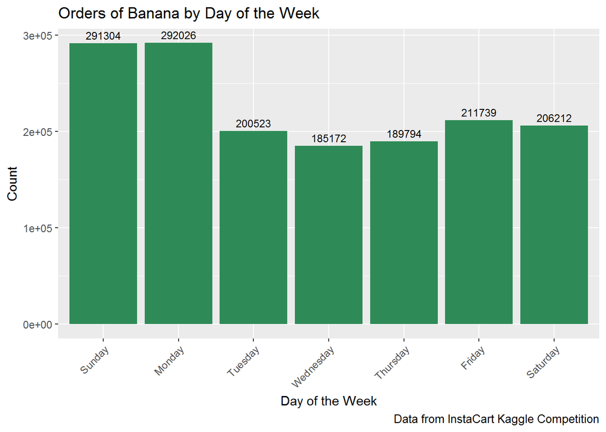

```r
orders %>%
  filter(product_name=="Banana") %>%
  group_by(order_dow) %>%
  summarize(order_n = sum(order_number)) %>%
  arrange(desc(order_n)) %>%
  ggplot(aes(x=order_dow, y=order_n)) +
  geom_bar(stat="identity",fill="seagreen4") +
  theme(axis.text.x=element_text(angle=45,hjust=1)) +
  geom_text(aes(label=order_n), size=3, vjust=-0.5) +
  labs(x="Day of the Week", y="Count",
       title="Orders of Banana by Day of the Week",
       caption="Data from InstaCart Kaggle Competition")
```

### 1b) Reorders by Day of the Week

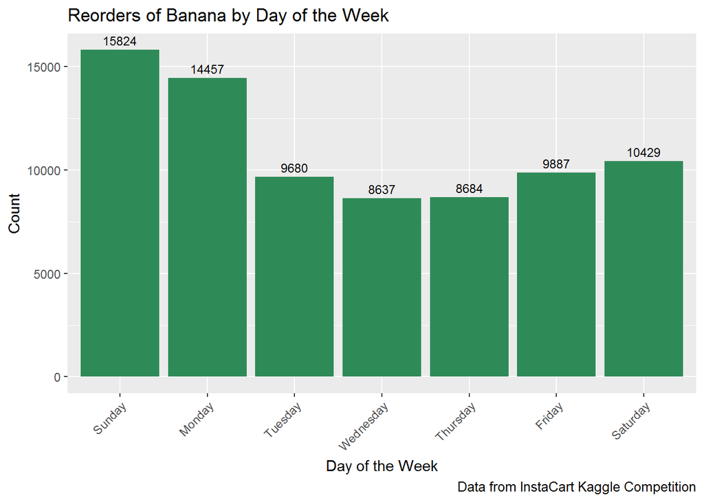

```r
orders %>%
  filter(product_name=="Banana") %>%
  group_by(order_dow) %>%
  summarize(reorder_n = sum(reordered)) %>%
  arrange(desc(reorder_n)) %>%
  ggplot(aes(x=order_dow, y=reorder_n)) +
  geom_bar(stat="identity",fill="seagreen4") +
  theme(axis.text.x=element_text(angle=45,hjust=1)) +
  geom_text(aes(label=reorder_n), size=3, vjust=-0.5) +
  labs(x="Day of the Week", y="Count",
       title="Reorders of Banana by Day of the Week",
       caption="Data from InstaCart Kaggle Competition")
```

### 1c) Orders & Reorders by Day of the Week

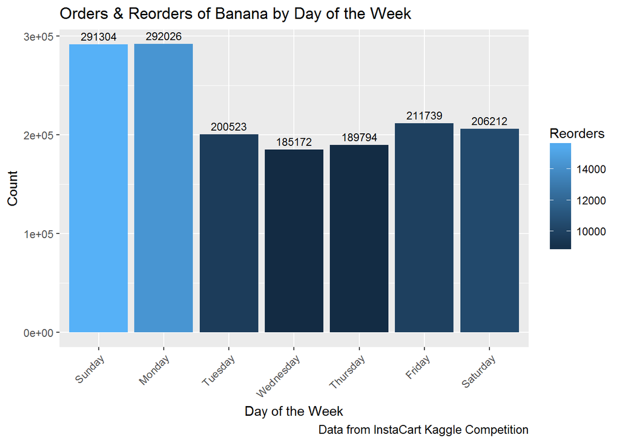

```r
orders %>%
  filter(product_name == "Banana",
         !is.na(order_dow)) %>%
  group_by(order_dow) %>%
  summarize(order_n = sum(order_number),
            reorder_n = sum(reordered)) %>%
  arrange(desc(order_n)) %>%
  ggplot(aes(x=order_dow, y=order_n, fill=reorder_n)) +
  geom_bar(stat="identity") +
  theme(axis.text.x=element_text(angle=45,hjust=1)) +
  geom_text(aes(label=order_n), size=3, vjust=-0.5) +
  labs(x="Day of the Week", y="Count",
       title="Orders & Reorders of Banana by Day of the Week",
       fill="Reorders",
       caption="Data from InstaCart Kaggle Competition")
```

## 1d) Orders by Time of the Day & Day of the Week

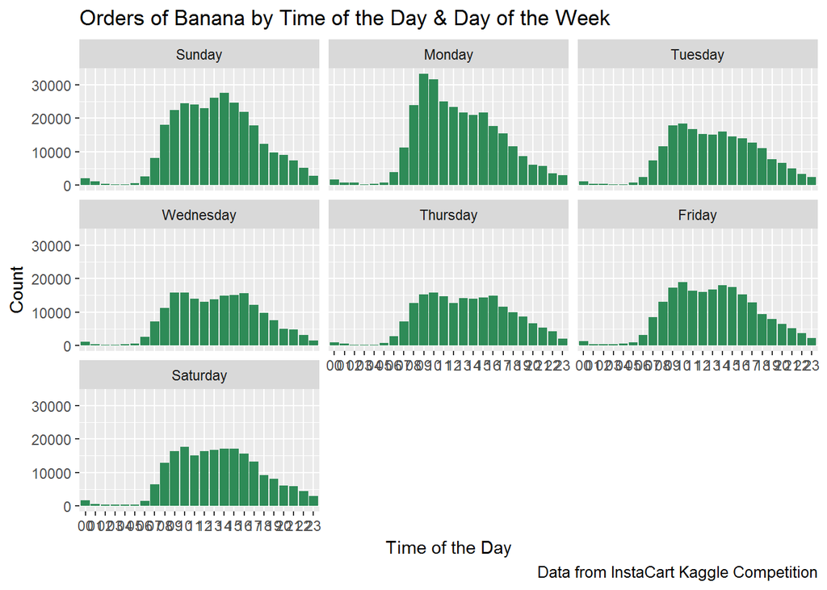

```r
orders %>%
  filter(product_name == "Banana") %>%
  group_by(order_dow, order_hour_of_day) %>%
  summarize(order_n = sum(order_number)) %>%
  ggplot(aes(x=order_hour_of_day, y=order_n)) +
  geom_bar(stat="identity", fill="seagreen4") +
  facet_wrap(~order_dow) +
  labs(x="Time of the Day", y="Count",
       title="Orders of Banana by Time of the Day & Day of the Week",
       caption="Data from InstaCart Kaggle Competition")
```

## 1e) Reorders by Time of the Day & Day of the Week

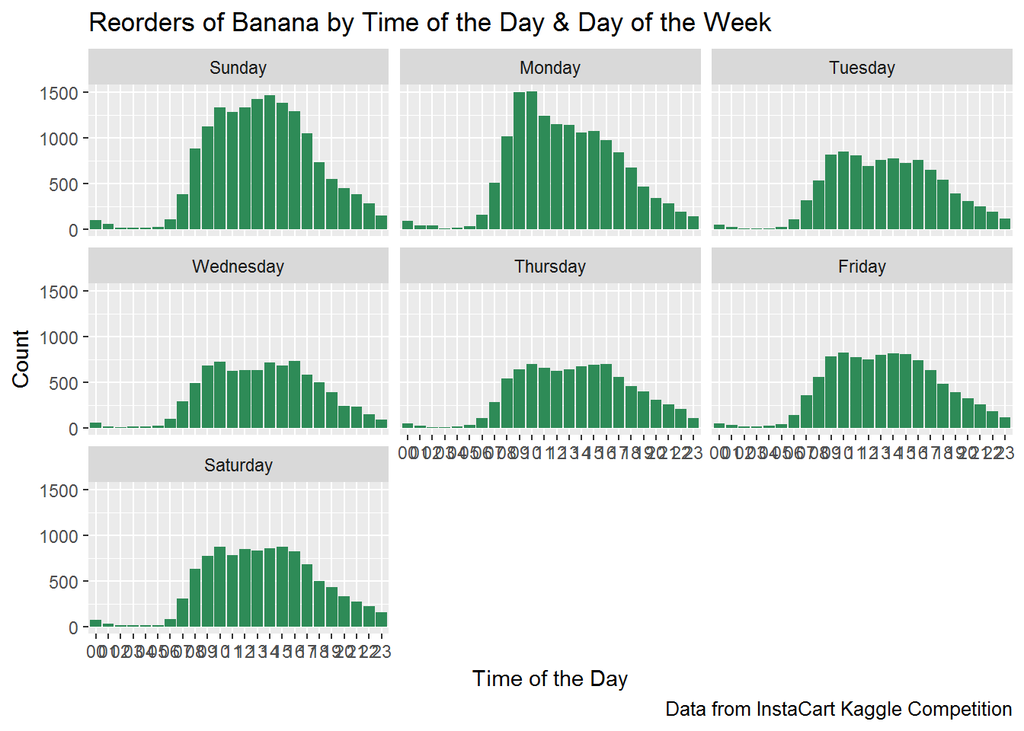

```r
orders %>%
  filter(product_name == "Banana") %>%
  group_by(order_dow, order_hour_of_day) %>%
  summarize(reorder_n = sum(reordered)) %>%
  ggplot(aes(x=order_hour_of_day, y=reorder_n)) +
  geom_bar(stat="identity", fill="seagreen4") +
  facet_wrap(~order_dow) +
  labs(x="Time of the Day", y="Count",
       title="Reorders of Banana by Time of the Day & Day of the Week",
       caption="Data from InstaCart Kaggle Competition")
```

## 1g) Orders & Reorders by Time of the Day & Day of the Week

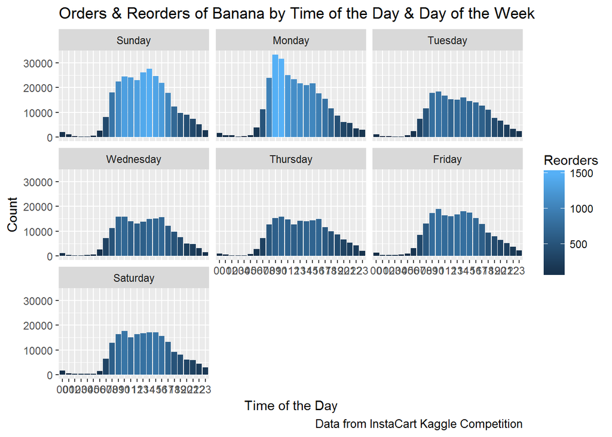

```r
orders %>%
  filter(product_name == "Banana",
         !is.na(order_dow)) %>%
  group_by(order_dow, order_hour_of_day) %>%
  summarize(order_n = sum(order_number),
            reorder_n = sum(reordered)) %>%
  ggplot(aes(x=order_hour_of_day, y=order_n, fill=reorder_n)) +
  geom_bar(stat="identity") +
  facet_wrap(~order_dow) +
  labs(x="Time of the Day", y="Count",
       title="Orders & Reorders of Banana by Time of the Day & Day of the Week",
       fill="Reorders",
       caption="Data from InstaCart Kaggle Competition")
```

## 1h) Reorder-Order Ratio by Time of the Day & Day of the Week

### A)

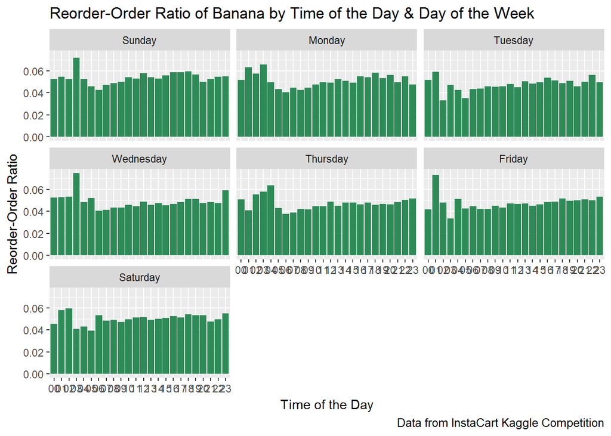

```r
orders %>%
  filter(product_name == "Banana") %>%
  group_by(order_dow, order_hour_of_day) %>%
  summarize(order_n = sum(order_number),
            reorder_n = sum(reordered)) %>%
  mutate(reord_ord = reorder_n/order_n) %>%
  ggplot(aes(x=order_hour_of_day, y=reord_ord)) +
  geom_bar(stat="identity", fill="seagreen4") +
  facet_wrap(~order_dow) +
  labs(x="Time of the Day", y="Reorder-Order Ratio",
       title="Reorder-Order Ratio of Banana by Time of the Day & Day of the Week",
       caption="Data from InstaCart Kaggle Competition")
```

### B)

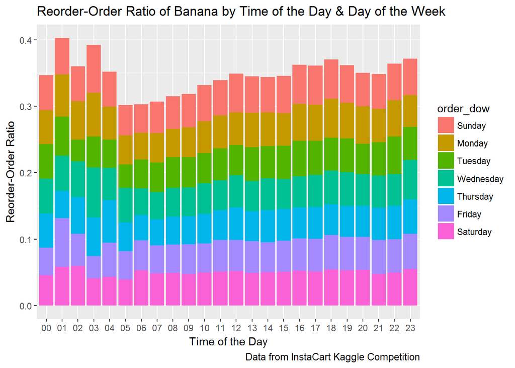

```r
orders %>%
  filter(product_name == "Banana") %>%
  group_by(order_dow, order_hour_of_day) %>%
  summarize(order_n = sum(order_number),
            reorder_n = sum(reordered)) %>%
  mutate(reord_ord = reorder_n/order_n) %>%
  ggplot(aes(x=order_hour_of_day, y=reord_ord, fill=order_dow)) +
  geom_bar(stat="identity") +
  labs(x="Time of the Day", y="Reorder-Order Ratio",
       title="Reorder-Order Ratio of Banana by Time of the Day & Day of the Week",
       caption="Data from InstaCart Kaggle Competition")
```

## 1i) The Reorder-Order Ratio of Top 10 Users with the Highest Banana Orders

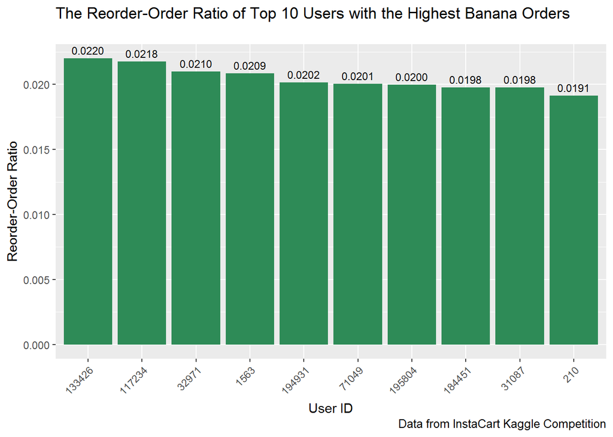

```r
orders %>%
  filter(product_name == "Banana") %>%
  group_by(user_id) %>%
  summarize(order_n = sum(order_number),
            reorder_n = sum(reordered)) %>%
  arrange(desc(order_n)) %>%
  head(n=10) %>%
  mutate(reord_ord = reorder_n/order_n) %>%
  ggplot(aes(x=reorder(user_id, -reord_ord), y=reord_ord)) +
  geom_bar(stat="identity", fill="seagreen4") +
  theme(axis.text.x=element_text(angle=45,hjust=1)) +
  geom_text(aes(label=format(round(reord_ord,4), nsmall=4)), size=3, vjust=-0.5) +
  labs(title="The Reorder-Order Ratio of Top 10 Users with the Highest Banana Orders",
       subtitle="",
       x="User ID", y="Reorder-Order Ratio",
       caption="Data from InstaCart Kaggle Competition")
```

## 1j) The Top 10 Reorder-Order Ratio Among the Top 300 Users with the Highest Banana Orders

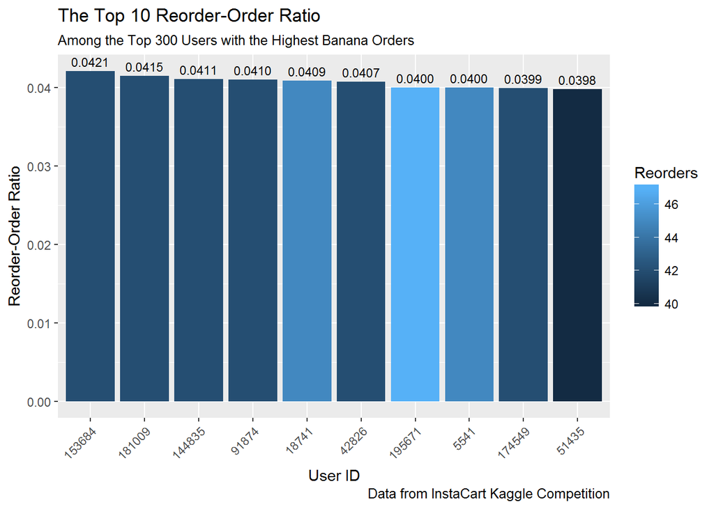

```r
orders %>%
  filter(product_name == "Banana") %>%
  group_by(user_id) %>%
  summarize(order_n = sum(order_number),
            reorder_n = sum(reordered)) %>%
  arrange(desc(order_n)) %>%
  head(n=300) %>%
  mutate(reord_ord = reorder_n/order_n) %>%
  arrange(desc(reord_ord)) %>%
  head(n=10) %>%
  ggplot(aes(x=reorder(user_id, -reord_ord), y=reord_ord, fill=reorder_n)) +
  geom_bar(stat="identity") +
  theme(axis.text.x=element_text(angle=45,hjust=1)) +
  geom_text(aes(label=format(round(reord_ord,4), nsmall=4)), size=3, vjust=-0.5) +
  labs(title="The Top 10 Reorder-Order Ratio",
       subtitle="Among the Top 300 Users with the Highest Banana Orders",
       x="User ID", y="Reorder-Order Ratio", fill="Reorders",
       caption="Data from InstaCart Kaggle Competition")
```

## 1k) The Top 10 Reorder-Order Ratio Among the Top 600 Users with the Highest Banana Orders

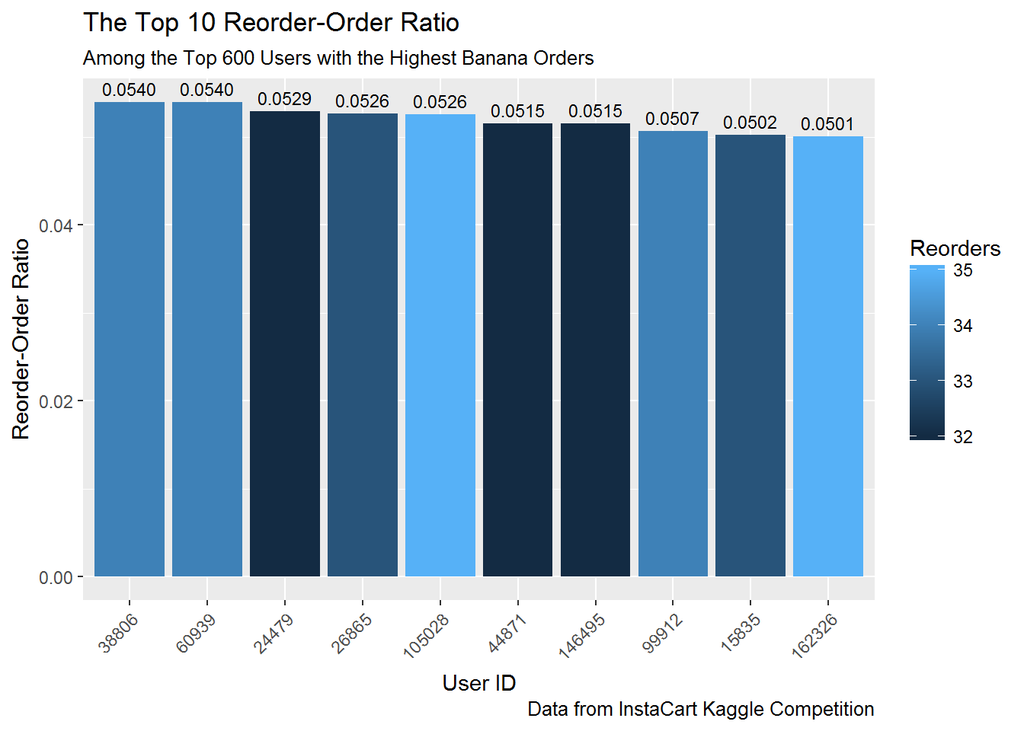

```r
orders %>%
  filter(product_name == "Banana") %>%
  group_by(user_id) %>%
  summarize(order_n = sum(order_number),
            reorder_n = sum(reordered)) %>%
  arrange(desc(order_n)) %>%
  head(n=600) %>%
  mutate(reord_ord = reorder_n/order_n) %>%
  arrange(desc(reord_ord)) %>%
  head(n=10) %>%
  ggplot(aes(x=reorder(user_id, -reord_ord), y=reord_ord, fill=reorder_n)) +
  geom_bar(stat="identity") +
  theme(axis.text.x=element_text(angle=45,hjust=1)) +
  geom_text(aes(label=format(round(reord_ord,4), nsmall=4)), size=3, vjust=-0.5) +
  labs(title="The Top 10 Reorder-Order Ratio",
       subtitle="Among the Top 600 Users with the Highest Banana Orders",
       x="User ID", y="Reorder-Order Ratio", fill="Reorders",
       caption="Data from InstaCart Kaggle Competition")
```

## 1l) The Top 10 Reorder-Order Ratio Among the Top 900 Users with the Highest Banana Orders

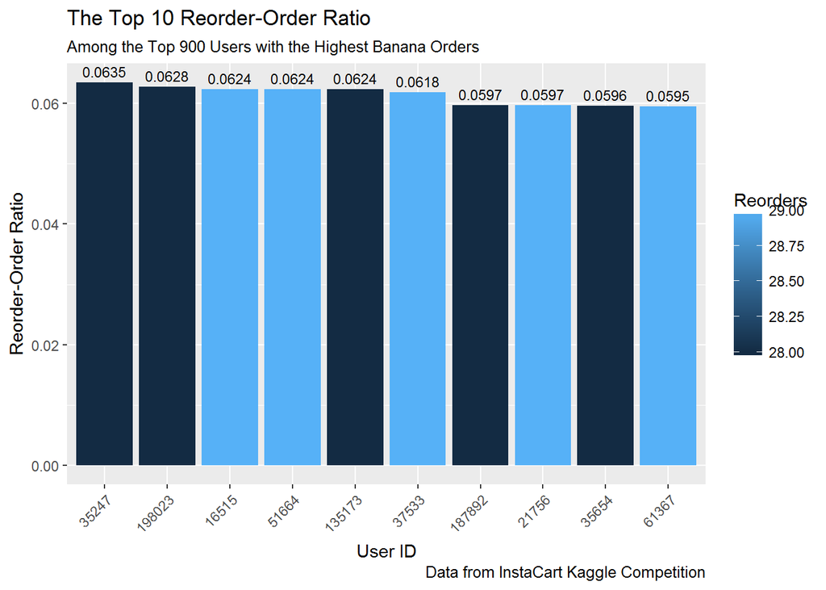

```r
orders %>%
  filter(product_name == "Banana") %>%
  group_by(user_id) %>%
  summarize(order_n = sum(order_number),
            reorder_n = sum(reordered)) %>%
  arrange(desc(order_n)) %>%
  head(n=900) %>%
  mutate(reord_ord = reorder_n/order_n) %>%
  arrange(desc(reord_ord)) %>%
  head(n=10) %>%
  ggplot(aes(x=reorder(user_id, -reord_ord), y=reord_ord, fill=reorder_n)) +
  geom_bar(stat="identity") +
  theme(axis.text.x=element_text(angle=45,hjust=1)) +
  geom_text(aes(label=format(round(reord_ord,4), nsmall=4)), size=3, vjust=-0.5) +
  labs(title="The Top 10 Reorder-Order Ratio",
       subtitle="Among the Top 900 Users with the Highest Banana Orders",
       x="User ID", y="Reorder-Order Ratio", fill="Reorders",
       caption="Data from InstaCart Kaggle Competition")
```

## Product Focus: `Avocados`

### 2a) Orders by Day of the Week

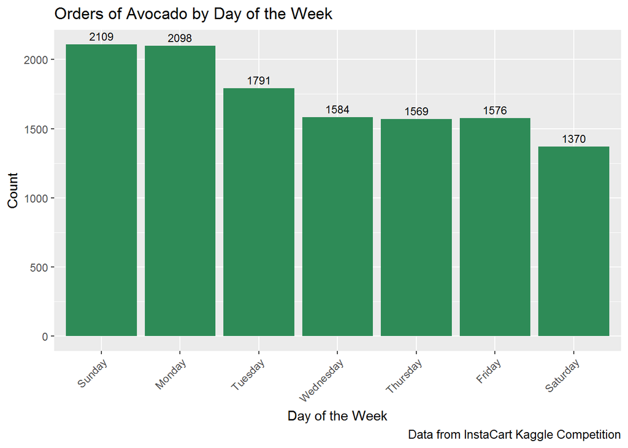

```r
orders %>%
  filter(product_name=="Avocado") %>%
  group_by(order_dow) %>%
  summarize(order_n = sum(order_number)) %>%
  arrange(desc(order_n)) %>%
  ggplot(aes(x=order_dow, y=order_n)) +
  geom_bar(stat="identity",fill="seagreen4") +
  theme(axis.text.x=element_text(angle=45,hjust=1)) +
  geom_text(aes(label=order_n), size=3, vjust=-0.5) +
  labs(x="Day of the Week", y="Count",
       title="Orders of Avocado by Day of the Week",
       caption="Data from InstaCart Kaggle Competition")
```

### 2b) Reorders by Day of the Week

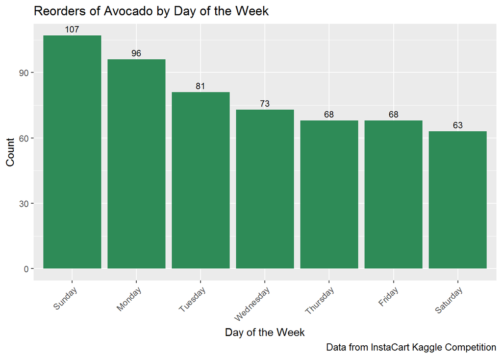

```r
orders %>%
  filter(product_name=="Avocado") %>%
  group_by(order_dow) %>%
  summarize(reorder_n = sum(reordered)) %>%
  arrange(desc(reorder_n)) %>%
  ggplot(aes(x=order_dow, y=reorder_n)) +
  geom_bar(stat="identity",fill="seagreen4") +
  theme(axis.text.x=element_text(angle=45,hjust=1)) +
  geom_text(aes(label=reorder_n), size=3, vjust=-0.5) +
  labs(x="Day of the Week", y="Count",
       title="Reorders of Avocado by Day of the Week",
       caption="Data from InstaCart Kaggle Competition")
```

### 2c) Orders & Reorders by Day of the Week

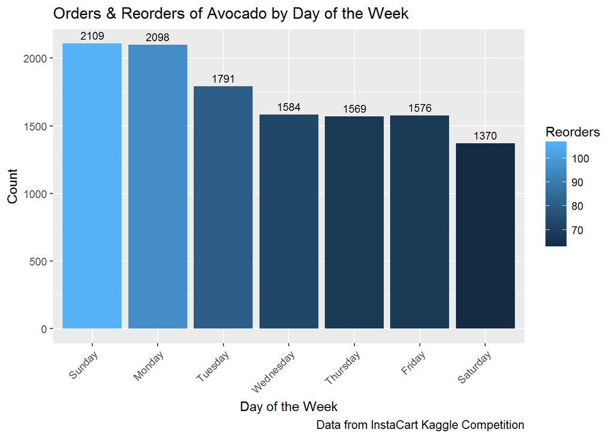

```r
orders %>%
  filter(product_name == "Avocado",
         !is.na(order_dow)) %>%
  group_by(order_dow) %>%
  summarize(order_n = sum(order_number),
            reorder_n = sum(reordered)) %>%
  arrange(desc(order_n)) %>%
  ggplot(aes(x=order_dow, y=order_n, fill=reorder_n)) +
  geom_bar(stat="identity") +
  theme(axis.text.x=element_text(angle=45,hjust=1)) +
  geom_text(aes(label=order_n), size=3, vjust=-0.5) +
  labs(x="Day of the Week", y="Count",
       title="Orders & Reorders of Avocado by Day of the Week",
       fill="Reorders",
       caption="Data from InstaCart Kaggle Competition")
```

## 2d) Orders by Time of the Day & Day of the Week

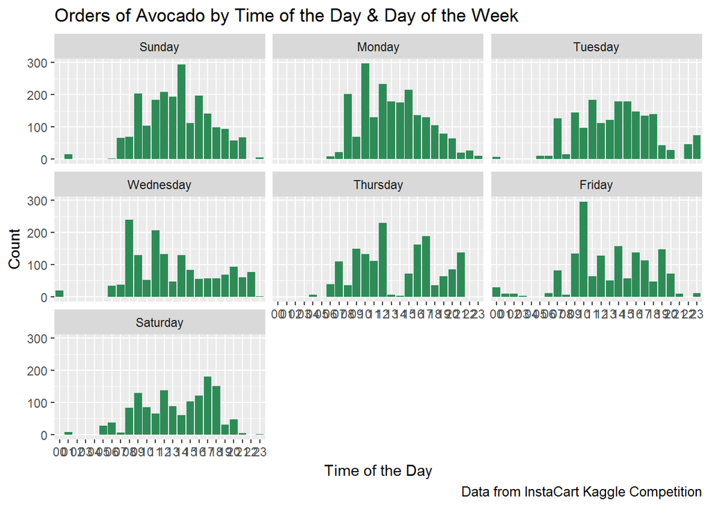

```r
orders %>%
  filter(product_name == "Avocado") %>%
  group_by(order_dow, order_hour_of_day) %>%
  summarize(order_n = sum(order_number)) %>%
  ggplot(aes(x=order_hour_of_day, y=order_n)) +
  geom_bar(stat="identity", fill="seagreen4") +
  facet_wrap(~order_dow) +
  labs(x="Time of the Day", y="Count",
       title="Orders of Avocado by Time of the Day & Day of the Week",
       caption="Data from InstaCart Kaggle Competition")
```

## 2e) Reorders by Time of the Day & Day of the Week

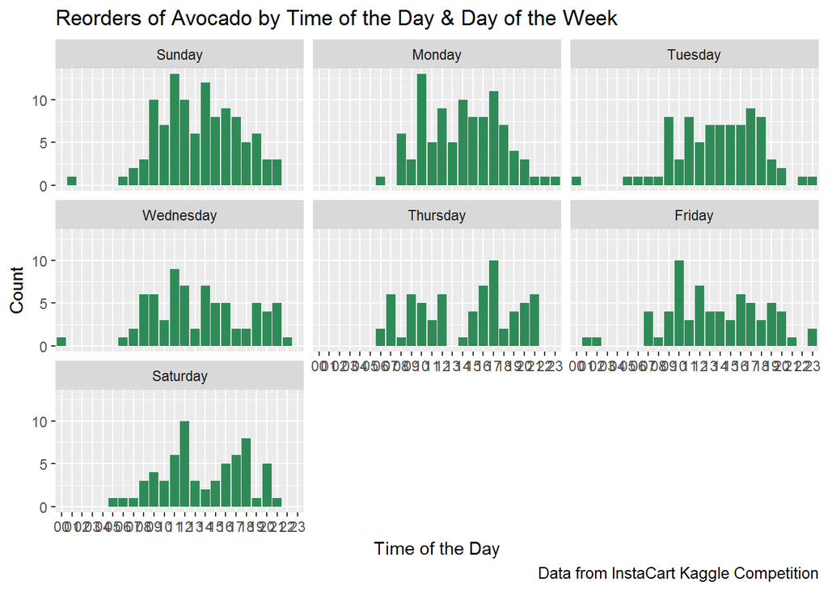

```r
orders %>%
  filter(product_name == "Avocado") %>%
  group_by(order_dow, order_hour_of_day) %>%
  summarize(reorder_n = sum(reordered)) %>%
  ggplot(aes(x=order_hour_of_day, y=reorder_n)) +
  geom_bar(stat="identity", fill="seagreen4") +
  facet_wrap(~order_dow) +
  labs(x="Time of the Day", y="Count",
       title="Reorders of Avocado by Time of the Day & Day of the Week",
       caption="Data from InstaCart Kaggle Competition")
```

## 2g) Orders & Reorders by Time of the Day & Day of the Week

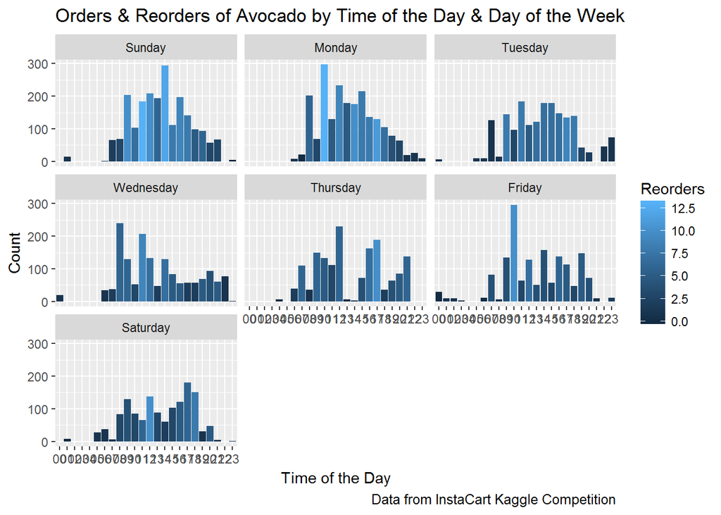

```r
orders %>%
  filter(product_name == "Avocado",
         !is.na(order_dow)) %>%
  group_by(order_dow, order_hour_of_day) %>%
  summarize(order_n = sum(order_number),
            reorder_n = sum(reordered)) %>%
  ggplot(aes(x=order_hour_of_day, y=order_n, fill=reorder_n)) +
  geom_bar(stat="identity") +
  facet_wrap(~order_dow) +
  labs(x="Time of the Day", y="Count",
       title="Orders & Reorders of Avocado by Time of the Day & Day of the Week",
       fill="Reorders",
       caption="Data from InstaCart Kaggle Competition")
```

## 2h) Reorder-Order Ratio by Time of the Day & Day of the Week

### A)

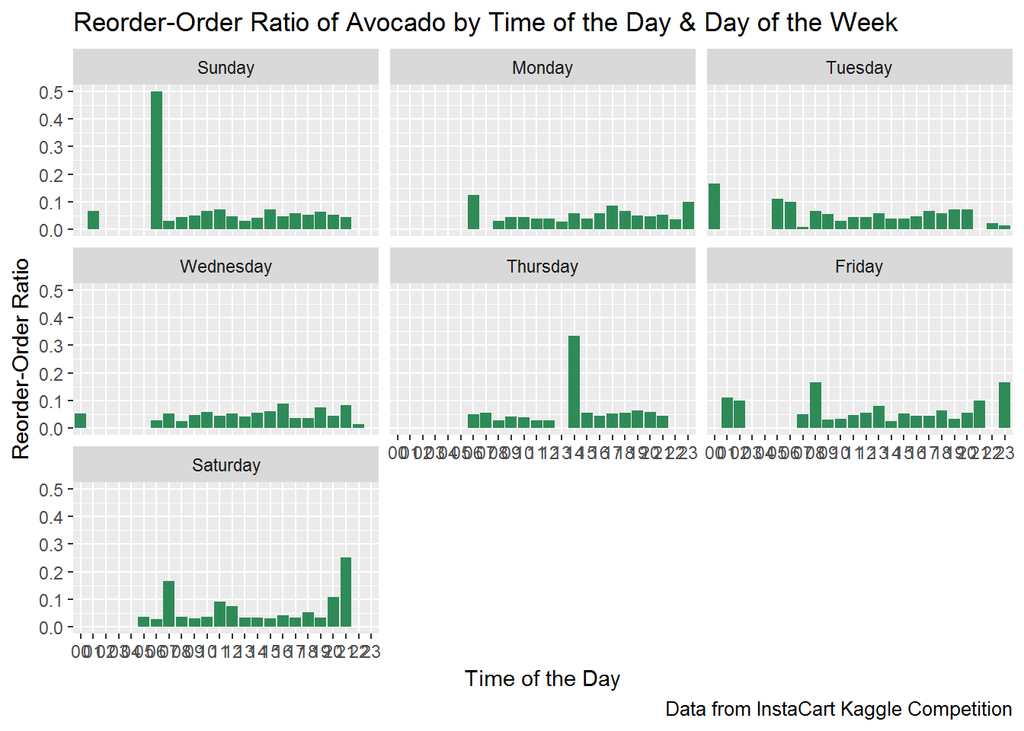

```r
orders %>%
  filter(product_name == "Avocado") %>%
  group_by(order_dow, order_hour_of_day) %>%
  summarize(order_n = sum(order_number),
            reorder_n = sum(reordered)) %>%
  mutate(reord_ord = reorder_n/order_n) %>%
  ggplot(aes(x=order_hour_of_day, y=reord_ord)) +
  geom_bar(stat="identity", fill="seagreen4") +
  facet_wrap(~order_dow) +
  labs(x="Time of the Day", y="Reorder-Order Ratio",
       title="Reorder-Order Ratio of Avocado by Time of the Day & Day of the Week",
       caption="Data from InstaCart Kaggle Competition")
```

### B)

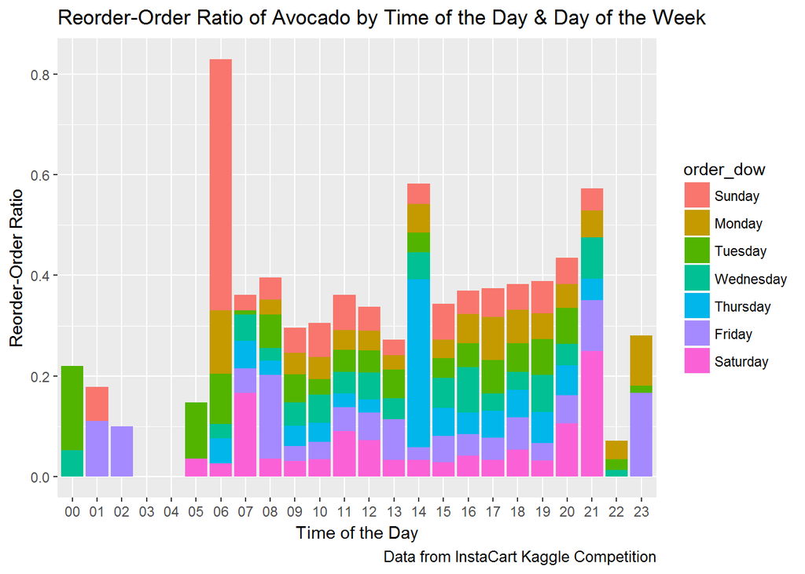

```r
orders %>%
  filter(product_name == "Avocado") %>%
  group_by(order_dow, order_hour_of_day) %>%
  summarize(order_n = sum(order_number),
            reorder_n = sum(reordered)) %>%
  mutate(reord_ord = reorder_n/order_n) %>%
  ggplot(aes(x=order_hour_of_day, y=reord_ord, fill=order_dow)) +
  geom_bar(stat="identity") +
  labs(x="Time of the Day", y="Reorder-Order Ratio",
       title="Reorder-Order Ratio of Avocado by Time of the Day & Day of the Week",
       caption="Data from InstaCart Kaggle Competition")
```

## 2i) The Reorder-Order Ratio of Top 10 Users with the Highest Avocado Orders

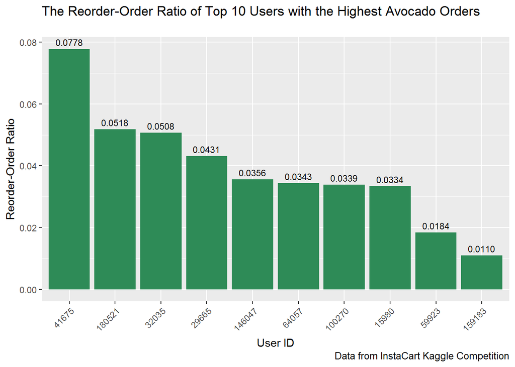

```r
orders %>%
  filter(product_name == "Avocado") %>%
  group_by(user_id) %>%
  summarize(order_n = sum(order_number),
            reorder_n = sum(reordered)) %>%
  arrange(desc(order_n)) %>%
  head(n=10) %>%
  mutate(reord_ord = reorder_n/order_n) %>%
  ggplot(aes(x=reorder(user_id, -reord_ord), y=reord_ord)) +
  geom_bar(stat="identity", fill="seagreen4") +
  theme(axis.text.x=element_text(angle=45,hjust=1)) +
  geom_text(aes(label=format(round(reord_ord,4), nsmall=4)), size=3, vjust=-0.5) +
  labs(title="The Reorder-Order Ratio of Top 10 Users with the Highest Avocado Orders",
       subtitle="",
       x="User ID", y="Reorder-Order Ratio",
       caption="Data from InstaCart Kaggle Competition")
```

## 2j) The Top 10 Reorder-Order Ratio Among the Top 300 Users with the Highest Avocado Orders

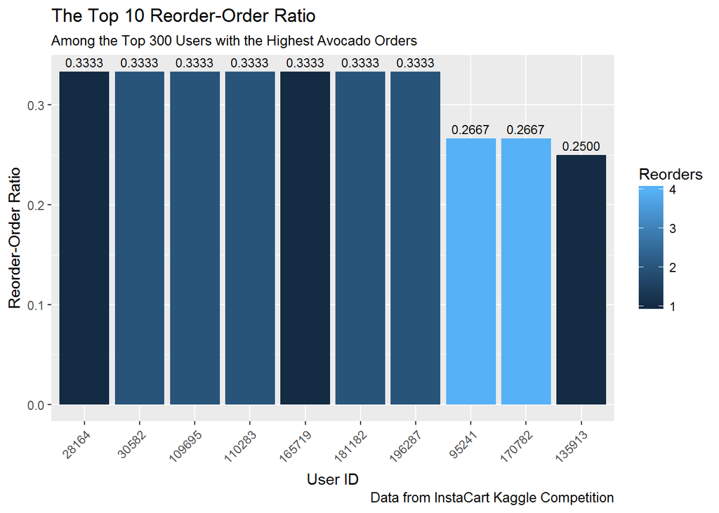

```r
orders %>%
  filter(product_name == "Avocado") %>%
  group_by(user_id) %>%
  summarize(order_n = sum(order_number),
            reorder_n = sum(reordered)) %>%
  arrange(desc(order_n)) %>%
  head(n=300) %>%
  mutate(reord_ord = reorder_n/order_n) %>%
  arrange(desc(reord_ord)) %>%
  head(n=10) %>%
  ggplot(aes(x=reorder(user_id, -reord_ord), y=reord_ord, fill=reorder_n)) +
  geom_bar(stat="identity") +
  theme(axis.text.x=element_text(angle=45,hjust=1)) +
  geom_text(aes(label=format(round(reord_ord,4), nsmall=4)), size=3, vjust=-0.5) +
  labs(title="The Top 10 Reorder-Order Ratio",
       subtitle="Among the Top 300 Users with the Highest Avocado Orders",
       x="User ID", y="Reorder-Order Ratio", fill="Reorders",
       caption="Data from InstaCart Kaggle Competition")
```

600 and 900 users with the highest avocado order was skipped because they did not differ from the plot given by the 300 users with the highest avocado order.

## Focus on: More with Reorder-Order Ratio

## 3a) The Top 10 Reorder-Order Ratio Among the Top 300 Product Name & Department Pair with the Highest Reorders by Department

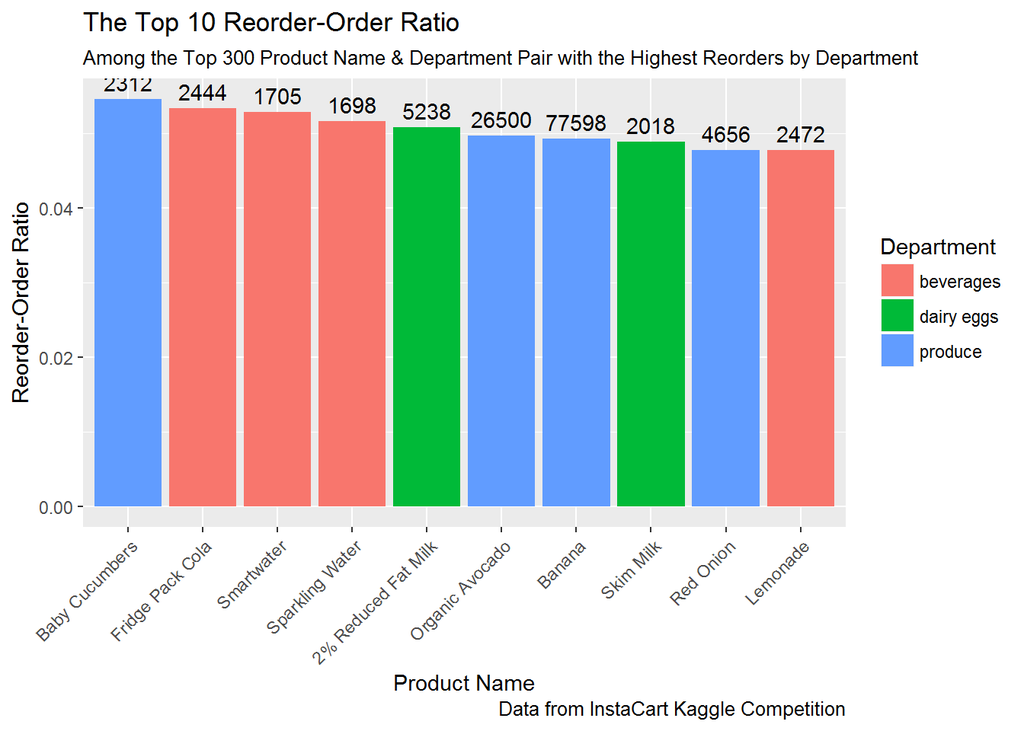

```r
orders %>%
  group_by(product_name, department) %>%
  summarize(order_n = sum(order_number),
            reorder_n = sum(reordered)) %>%
  arrange(desc(reorder_n)) %>%
  head(300) %>%
  mutate(reord_ord = reorder_n/order_n) %>%
  arrange(desc(reord_ord)) %>%
  head(10) %>%
  ggplot(aes(x = reorder(product_name, -reord_ord), y = reord_ord, fill = department)) +
  geom_bar(stat="identity", position = "dodge") +
  theme(axis.text.x=element_text(angle=45,hjust=1)) +
  geom_text(aes(label=reorder_n, nsmall=4, vjust = -0.5)) +
  labs(x="Product Name", y="Reorder-Order Ratio",
     title="The Top 10 Reorder-Order Ratio",
     subtitle="Among the Top 300 Product Name & Department Pair with the Highest Reorders by Department",
     fill="Department", caption="Data from InstaCart Kaggle Competition")
```

## 3b) The Top 10 Reorder-Order Ratio Among the Top 600 Product Name & Department Pair with the Highest Reorders by Department

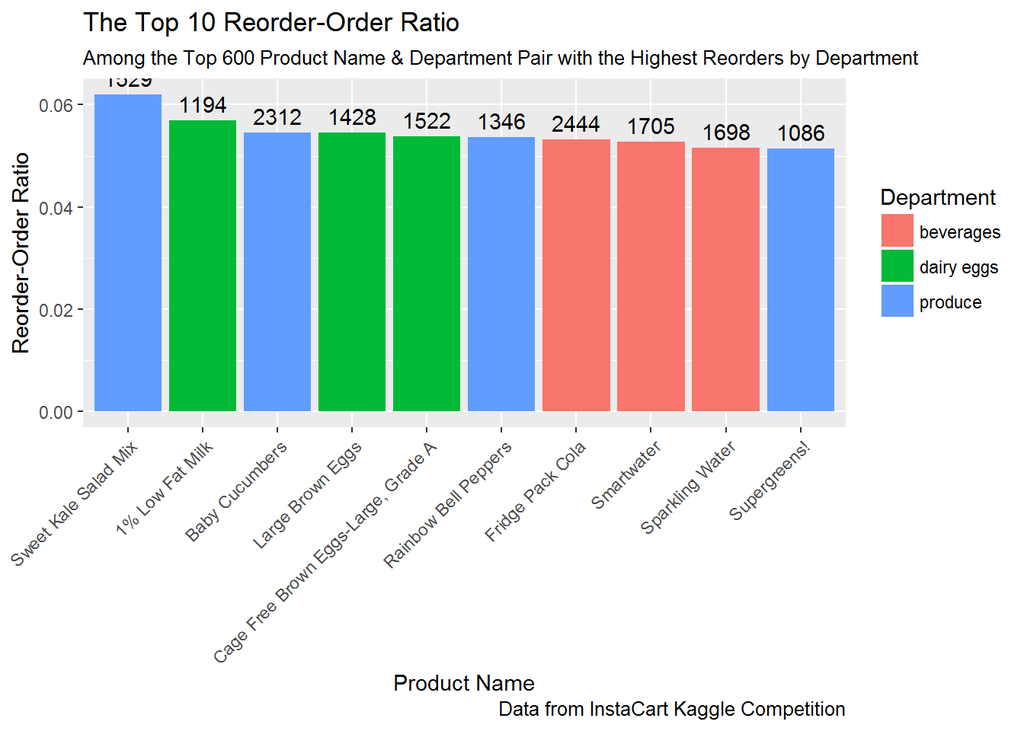

```r
orders %>%
  group_by(product_name, department) %>%
  summarize(order_n = sum(order_number),
            reorder_n = sum(reordered)) %>%
  arrange(desc(reorder_n)) %>%
  head(600) %>%
  mutate(reord_ord = reorder_n/order_n) %>%
  arrange(desc(reord_ord)) %>%
  head(10) %>%
  ggplot(aes(x = reorder(product_name, -reord_ord), y = reord_ord, fill = department)) +
  geom_bar(stat="identity", position = "dodge") +
  theme(axis.text.x=element_text(angle=45,hjust=1)) +
  geom_text(aes(label = reorder_n, vjust = -0.5)) +
  labs(x="Product Name", y="Reorder-Order Ratio",
     title="The Top 10 Reorder-Order Ratio",
     subtitle="Among the Top 600 Product Name & Department Pair with the Highest Reorders by Department",
     fill="Department", caption="Data from InstaCart Kaggle Competition")
```

## 3c) The Top 10 Reorder-Order Ratio Among the Top 900 Product Name & Department Pair with the Highest Reorders by Department

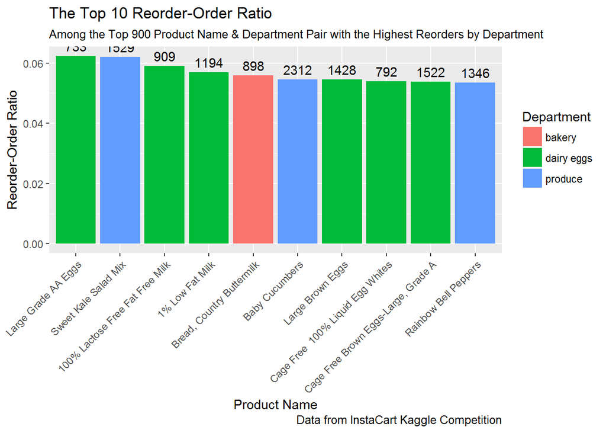

```r
orders %>%
  group_by(product_name, department) %>%
  summarize(order_n = sum(order_number),
            reorder_n = sum(reordered)) %>%
  arrange(desc(reorder_n)) %>%
  head(900) %>%
  mutate(reord_ord = reorder_n/order_n) %>%
  arrange(desc(reord_ord)) %>%
  head(10) %>%
  ggplot(aes(x = reorder(product_name, -reord_ord), y = reord_ord, fill = department)) +
  geom_bar(stat="identity", position = "dodge") +
  theme(axis.text.x=element_text(angle=45,hjust=1)) +
  geom_text(aes(label = reorder_n, vjust = -0.5)) +
  labs(x="Product Name", y="Reorder-Order Ratio",
     title="The Top 10 Reorder-Order Ratio",
     subtitle="Among the Top 900 Product Name & Department Pair with the Highest Reorders by Department",
     fill="Department", caption="Data from InstaCart Kaggle Competition")
```

## Focus on: The Logical Cut-off Method

## 4a) A Logical Cutoff for `order_n` & `reorder_n`

```r
tem <- orders %>%
  group_by(product_name, department) %>%
  summarize(order_n = sum(order_number),
            reorder_n = sum(reordered)) %>%
  arrange(desc(order_n))

print(lst(min_n = min(tem$order_n), max_n = max(tem$order_n),
          min_reo = min(tem$reorder_n), max_reo = max(tem$reorder_n),
          sd1_high_n = mean(tem$order_n)+sd(tem$order_n),
          sd2_high_n = mean(tem$order_n)+2*sd(tem$order_n),
          sd3_high_n = mean(tem$order_n)+3*sd(tem$order_n),
          sd1_high_reo = mean(tem$reorder_n)+sd(tem$reorder_n),
          sd2_high_reo = mean(tem$reorder_n)+2*sd(tem$reorder_n),
          sd3_high_reo = mean(tem$reorder_n)+3*sd(tem$reorder_n)))
```

```
## $min_n
## [1] 1
##
## $max_n
## [1] 1576770
##
## $min_reo
## [1] 0
##
## $max_reo
## [1] 77598
##
## $sd1_high_n
## [1] 19718.69
##
## $sd2_high_n
## [1] 37122.94
##
## $sd3_high_n
## [1] 54527.19
##
## $sd1_high_reo
## [1] 803.9717
##
## $sd2_high_reo
## [1] 1527.532
##
## $sd3_high_reo
## [1] 2251.092
```

```r
writeLines("The logical cutoff (+1 sd) for order_n is 19719, and that for reorder_n is 804. \nThe logical cutoff (+2 sd) for order_n is 37123, and that for reorder_n is 1528. \nThe logical cutoff (+3 sd) for order_n is 54527, and that for reorder_n is 2251.")
```

```
## The logical cutoff (+1 sd) for order_n is 19719, and that for reorder_n is 804.
## The logical cutoff (+2 sd) for order_n is 37123, and that for reorder_n is 1528.
## The logical cutoff (+3 sd) for order_n is 54527, and that for reorder_n is 2251.
```

```r
# alternative
# cat("The logical cutoff (+1 sd) for order_n is 19719, and that for reorder_n is 804. \nThe logical cutoff (+2 sd) for order_n is 37123, and that for reorder_n is 1528. \nThe logical cutoff (+3 sd) for order_n is 54527, and that for reorder_n is 2251.")

rm(sd3_low_n, sd2_low_n, sd1_low_n, sd1_high_n, sd2_high_n, sd3_high_n)
rm(sd3_low_reo, sd2_low_reo, sd1_low_reo, sd1_high_reo, sd2_high_reo, sd3_high_reo)
```

## 4b) Top 10 Reorder-Order Ratio by Products & Department with a +1 sd cutoff for `order_n`

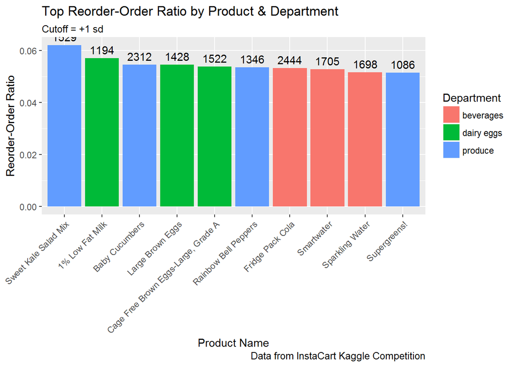

```r
orders %>%
  group_by(product_name, department) %>%
  summarize(order_n = sum(order_number),
            reorder_n = sum(reordered)) %>%
  filter(order_n >= 19719) %>%
  mutate(reord_ord = reorder_n/order_n) %>%
  arrange(desc(reord_ord)) %>%
  head(10) %>%
  ggplot(aes(x = reorder(product_name, -reord_ord), y = reord_ord, fill = department)) +
  geom_bar(stat="identity", position = "dodge") +
  theme(axis.text.x=element_text(angle=45,hjust=1)) +
  geom_text(aes(label = reorder_n, vjust = -0.5)) +
  labs(x="Product Name", y="Reorder-Order Ratio",
     title="Top Reorder-Order Ratio by Product & Department", subtitle="Cutoff = +1 sd",
     fill="Department", caption="Data from InstaCart Kaggle Competition")
```

## 4c) Focus on: Top 10 Reorder-Order Ratio by Products & Department with a +2 sd cutoff for `order_n`

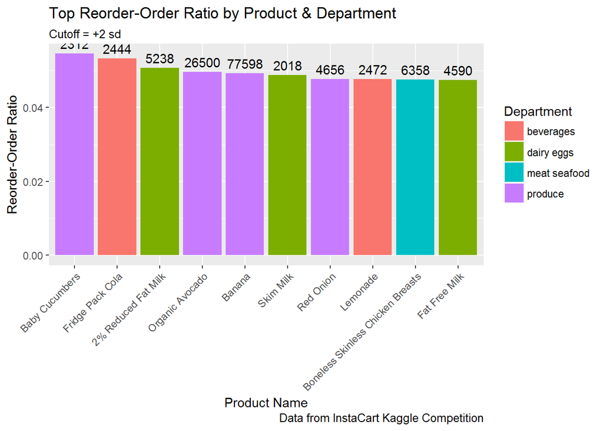

```r
orders %>%
  group_by(product_name, department) %>%
  summarize(order_n = sum(order_number),
            reorder_n = sum(reordered)) %>%
  filter(order_n >= 37123) %>%
  mutate(reord_ord = reorder_n/order_n) %>%
  arrange(desc(reord_ord)) %>%
  head(10) %>%
  ggplot(aes(x = reorder(product_name, -reord_ord), y = reord_ord, fill = department)) +
  geom_bar(stat="identity", position = "dodge") +
  theme(axis.text.x=element_text(angle=45,hjust=1)) +
  geom_text(aes(label = reorder_n, vjust = -0.5)) +
  labs(x="Product Name", y="Reorder-Order Ratio",
     title="Top Reorder-Order Ratio by Product & Department", subtitle="Cutoff = +2 sd",
     fill="Department", caption="Data from InstaCart Kaggle Competition")
```

## 4d) Focus on: Top 10 Reorder-Order Ratio by Products & Department with a +3 sd cutoff for `order_n`

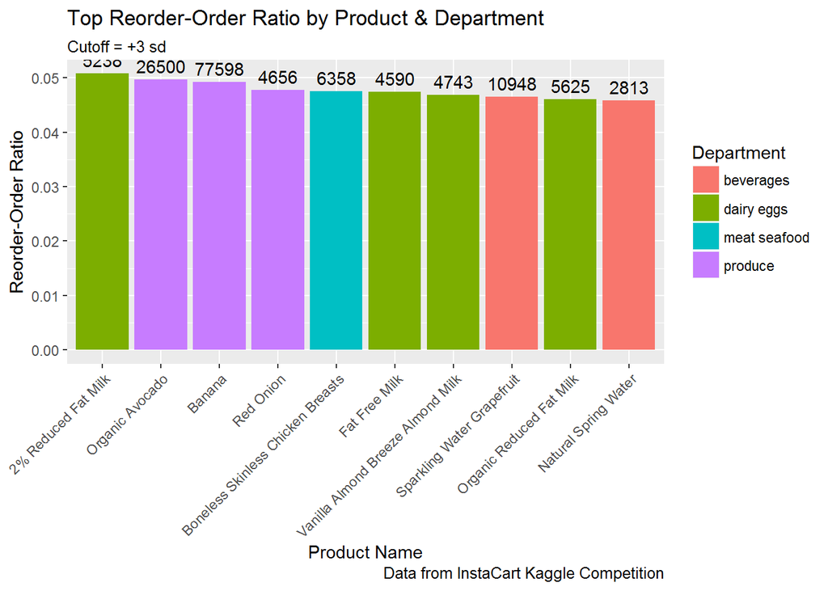

```r
orders %>%
  group_by(product_name, department) %>%
  summarize(order_n = sum(order_number),
            reorder_n = sum(reordered)) %>%
  filter(order_n >= 54527) %>%
  mutate(reord_ord = reorder_n/order_n) %>%
  arrange(desc(reord_ord)) %>%
  head(10) %>%
  ggplot(aes(x = reorder(product_name, -reord_ord), y = reord_ord, fill = department)) +
  geom_bar(stat="identity", position = "dodge") +
  theme(axis.text.x=element_text(angle=45,hjust=1)) +
  geom_text(aes(label = reorder_n, vjust = -0.5)) +
  labs(x="Product Name", y="Reorder-Order Ratio",
     title="Top Reorder-Order Ratio by Product & Department", subtitle="Cutoff = +3 sd",
     fill="Department", caption="Data from InstaCart Kaggle Competition")
```